# *TP MSS - Marches Aléatoires le cas binomiale*

## *Octobre 2020*

### Marche Aléatoire

Soit $S_{n} = S_{n−1} + X_{n}$ avec $S_{0} = 0$, une marche aléatoire . On s’intéresse à des marches aléatoires de N pas et à la distribution $P(S_{N})$ de la position finale $S_{N}$ d’une particule qui se déplace sur un axe.

## 1. Loi Binomiale :

Le pas $$Xn = \left\{ \begin{array}\\ 1 & \mbox{probabilité }\ p\\ -1 & \mbox{probabilité }\ 1-p \end{array}\right.$$

### 1.1.1 Question 1 :

Générer quelques marches aléatoires de $N = 10000$ pas pour $p = 0.4, 0.49$ et $0.5$.

### 1.1.2 Réponse 1 :

- On commence par définir une fonction simuler_pas qui simule la valeur d'un pas (+1 ou -1)
- Les entrées de la fonction sont : la probabilité $p$

```python
import numpy as np
import pandas as pd
import matplotlib.pyplot as plt
%matplotlib inline
from math import *
def simuler_pas(p):
    u=np.random.uniform(0,1)
    if (u<p):
        pas = 1
    else :
        pas = -1
    return pas
```

- On définit par la suite une fonction simuler_marche_aléatoire qui simule la marche aléatoire
- Les entrées de la fonction sont : le nombre de pas de la marche et la probabilité $p$
- La fonction retourne un tableau qui représente la marche

```python
def simuler_marche_aleatoire(n,p):
    s=0
    marche=[s]
    for i in range(n):
        s += simuler_pas(p)
        marche.append(s)
    return marche
```

- On génère les marches demandées
- Pour chaque valeur de $p$ on affiche uniquement les 10 premières position et la position finale des 3 premières simulations.
- **Pour $p$ = 0.4**

```python
s1 = [] # tableau qui comporte les marches aléatoires de pas = 10000 et p = 0.4
for i in range(50):
    m = simuler_marche_aleatoire(10000,0.4)
    s1.append(m)
for s in s1[:3]:
    print ( 'Les 10 premières position (10 premières valeurs de Sn) de la marche : ',s[:10])
    print ( 'La position finale de la marche : ',s[10000])
    print ('')
```

```
Les 10 premières position (10 premières valeurs de Sn) de la marche :  [0, -1, -2, -3, -2, -1, -2, -3, -4, -5]
La position finale de la marche :  -2058

Les 10 premières position (10 premières valeurs de Sn) de la marche :  [0, -1, -2, -3, -4, -5, -4, -5, -6, -5]
La position finale de la marche :  -1958

Les 10 premières position (10 premières valeurs de Sn) de la marche :  [0, 1, 0, -1, 0, 1, 2, 3, 2, 1]
La position finale de la marche :  -2042
```

- **Pour $p$ = 0.49**

```python
s2 = [] # tableau qui comporte les marches aléatoires de pas = 10000 et p = 0.49
for i in range(50):
    m = simuler_marche_aleatoire(10000,0.49)
    s2.append(m)
for s in s2[:3]:
    print ( 'Les 10 premières position (10 premières valeurs de Sn) de la marche : ',s[:10])
    print ( 'La position finale de la marche : ',s[10000])
    print ('')
```

```
Les 10 premières position (10 premières valeurs de Sn) de la marche :  [0, 1, 0, -1, -2, -1, 0, 1, 0, -1]
La position finale de la marche :  -382

Les 10 premières position (10 premières valeurs de Sn) de la marche :  [0, 1, 0, -1, 0, 1, 2, 1, 2, 1]
La position finale de la marche :  -184

Les 10 premières position (10 premières valeurs de Sn) de la marche :  [0, 1, 2, 1, 0, 1, 0, 1, 0, 1]
La position finale de la marche :  -242
```

- **Pour $p$ = 0.5**

```python
s3 = [] # tableau qui comporte les marches aléatoires de pas = 10000 et p = 0.5
for i in range(50):
    m = simuler_marche_aleatoire(10000,0.5)
    s3.append(m)
for s in s3[:3]:
    print ( 'Les 10 premières position (10 premières valeurs de Sn) de la marche : ',s[:10])
    print ( 'La position finale de la marche : ',s[10000])
    print ('')
```

```
Les 10 premières position (10 premières valeurs de Sn) de la marche :  [0, -1, -2, -3, -4, -3, -4, -3, -2, -1]
La position finale de la marche :  68

Les 10 premières position (10 premières valeurs de Sn) de la marche :  [0, 1, 0, 1, 2, 3, 2, 1, 2, 1]
La position finale de la marche :  192

Les 10 premières position (10 premières valeurs de Sn) de la marche :  [0, -1, -2, -3, -4, -5, -6, -7, -8, -7]
La position finale de la marche :  160
```

### 1.2.1 Question 2 :

Tracer ces marches aléatoires ($S_{n}$ en fonction de $n$).

### 1.2.2 Réponse 2 :

- On trace 3 simulations pour chaque valeur de $p$
- On trace toutes les marches sur le meme graphe pour pouvoir comparer.
- Les couleurs sont comme suit :
  - $p=0.4$ ---> couleur Bleue
  - $p=0.49$ ---> couleur Rouge
  - $p=0.5$ ---> couleur Verte

```
<function matplotlib.pyplot.show(*args, **kw)>
```

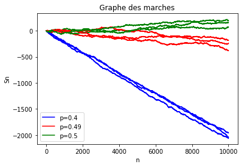

```python
X = np.linspace(0, 10000, 10001)
for i in range(3):
    if (i==0):
        plt.plot(X,s1[i],color = "blue",label="p=0.4")
        plt.plot(X,s2[i],color = "red",label="p=0.49")
        plt.plot(X,s3[i],color = "green",label="p=0.5")
    else:
        plt.plot(X,s1[i],color = "blue")
        plt.plot(X,s2[i],color = "red")
        plt.plot(X,s3[i],color = "green")
plt.title("Graphe des marches")
plt.xlabel('n')
plt.ylabel('Sn')
plt.legend()
plt.show
```

### 1.3.1 Question 3 :

Quelle est la trajectoire moyenne $< S_{n} >$ pour chaque valeur de $p$ ?

### 1.3.2 Réponse 3 :

- On définit une fonction qui calcule la trajectoire moyenne $< S_{n} >$ pour un ensemble de marches aléatoires.
- Pour chaque trajectoire moyenne on affiche les 10 premières et les 10 dernières positions ( valeurs de $< S_{n} >$ )

```python
def calculer_trajectoire_moyenne (E): # E est l'ensemble des marches aleatoires
    res = []
    nb_marches = len(E) # nombre de marches
    nb_pas = len(E[0]) # nombre de pas dans les marches
    for i in range (nb_pas):
        for num_marche in range(nb_marches):
            if (num_marche==0):
                res.append(E[num_marche][i])
            else:
                res[i] += E[num_marche][i]
        res[i] = res[i]/nb_marches
    return res
```

- **Pour $p$ = 0.4 :**

```python
moy = calculer_trajectoire_moyenne(s1)
print('Les 10 premières composantes de < Sn > sont : ',moy[:10])
print('Les 10 dernières composantes de < Sn > sont : ',moy[-10:])
```

```
Les 10 premières composantes de < Sn > sont :  [0.0, -0.12, -0.2, -0.4, -0.48, -0.8, -0.8, -0.76, -1.12, -1.32]
Les 10 dernières composantes de < Sn > sont :  [-1994.96, -1995.04, -1995.52, -1995.88, -1995.96, -1996.28, -1996.48, -1996.8, -1997.24, -1997.48]
```

- **Pour $p$ = 0.49 :**

```python
moy = calculer_trajectoire_moyenne(s2)
print('Les 10 premières composantes de < Sn > sont : ',moy[:10])
print('Les 10 dernières composantes de < Sn > sont : ',moy[-10:])
```

```
Les 10 premières composantes de < Sn > sont :  [0.0, 0.2, 0.04, 0.08, 0.24, 0.32, 0.36, 0.2, -0.08, 0.0]
Les 10 dernières composantes de < Sn > sont :  [-199.04, -198.72, -198.68, -198.92, -198.64, -198.64, -198.76, -198.88, -198.84, -198.64]
```

- **Pour $p$ = 0.5 :**

```python
moy = calculer_trajectoire_moyenne(s3)
print('Les 10 premières composantes de < Sn > sont : ',moy[:10])
print('Les 10 dernières composantes de < Sn > sont : ',moy[-10:])
```

```
Les 10 premières composantes de < Sn > sont :  [0.0, -0.2, -0.4, -0.32, -0.24, -0.16, -0.2, 0.0, 0.24, 0.44]
Les 10 dernières composantes de < Sn > sont :  [-9.4, -9.52, -9.6, -9.48, -9.56, -9.4, -9.4, -9.36, -9.28, -9.16]
```

Observer l’aspect d’une marche aléatoire $M$ symétrique ($p$ = 0.5) de $N$ = 10000 pas.

Soit $M′$ la marche aléatoire obtenue à partir des 1000 premiers pas de $M$.

### 1.4.1 Question 4 :

Tracer sur un même graphe $M$ et $M′$ en multipliant la taille des itérations (axe des abscisses) de cette dernière par 10.

### 1.4.2 Réponse 4 :

```
<function matplotlib.pyplot.show(*args, **kw)>
```

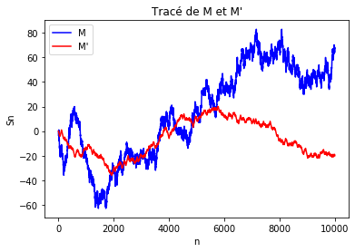

```python
M = s3[0]
Mprime = M[:1001]
X = np.linspace(0, 10000, 10001)
plt.plot(X,M,color = "blue",label = "M")
X = np.linspace(0, 10000, 1001)
plt.plot(X,Mprime,color = "red",label = "M'")
plt.title("Tracé de M et M'")
plt.xlabel('n')
plt.ylabel('Sn')
plt.legend()
plt.show
```

**Question :** Par quel facteur faut-il multiplier la taille des pas (axe des ordonnées) de $M′$ pour que les deux marches aléatoires aient le même aspect ?

**Réponse :** il n y a aucun facteur par lequel on multiplie la taille des pas de $M'$ pour que les deux marches aléatoires aient le meme aspect car les pas de 1000 à 10000 sont aléatoires et donc indépendants des pas de 0 à 1000

### 1.5.1 Question 5 :

Reprendre la même procédure avec $M′′$, la marche aléatoire obtenue à partir des 100 premiers pas de $M$.

### 1.5.2 Réponse 5 :

```
<function matplotlib.pyplot.show(*args, **kw)>
```

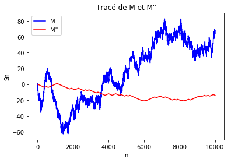

```python
M = s3[0]
Mprimeprime = M[:101]
X = np.linspace(0, 10000, 10001)
plt.plot(X,M,color = "blue",label = "M")
X = np.linspace(0, 10000, 101)
plt.plot(X,Mprimeprime,color = "red",label = "M''")
plt.title("Tracé de M et M''")
plt.xlabel('n')
plt.ylabel('Sn')
plt.legend()
plt.show
```

**Question :** Par quel facteur faut-il multiplier la taille des pas (axe des ordonnées) de $M''$pour que les deux marches aléatoires aient le même aspect ?

**Réponse :** il n y a aucun facteur par lequel on multiplie la taille des pas de $M''$ pour que les deux marches aléatoires aient le meme aspect car les pas de 100 à 10000 sont aléatoires et donc indépendants des pas de 0 à 100.

### 1.6.1 Question 6 :

Pour $p$ $= 0.5$, générer $M$ $= 10^q$ (d’abord pour $q$ $= 1$, puis $q$ $= 2$, $3$et$4$) marches aléatoires de $N$ $= 10000$ pas et calculer $< S_{n} >_{q}$ et $\sqrt{Var(S_{n})_{q}}$ pour $n$ $≤$ $N$.

### 1.6.2 Réponse 6 :

```python
def calculer_racine_variance (E): # E est l'ensemble des marches aleatoires
    moy = calculer_trajectoire_moyenne(E)
    res = []
    nb_marches = len(E) # nombre de marches
    nb_pas = len(E[0]) # nombre de pas dans les marches
    for i in range(nb_pas):
        for num_marche in range (nb_marches):
            if (num_marche==0):
                res.append((E[num_marche][i]-moy[i])**2)
            else:
                res[i] += ((E[num_marche][i]-moy[i])**2)
    res[i] = sqrt(res[i]/nb_marches)
    return res
```

- $q$ $= 1$

```python
q1 = [] # tableau qui comporte les marches aléatoires de pas = 10000 et p = 0.5
for i in range(10):
    m = simuler_marche_aleatoire(10000,0.5)
    q1.append(m)
moy1 = calculer_trajectoire_moyenne(q1)
racine_var1 = calculer_racine_variance(q1)
print('Les 10 premières composantes de < Sn > sont : ',moy1[:10])
print('Les 10 dernières composantes de < Sn > sont : ',moy1[-10:])
print("Les 10 premières composantes de l'ecart type sont : ",racine_var1[:10])
print("Les 10 dernières composantes de l'ecart type sont : ",racine_var1[-10:])
```

```
Les 10 premières composantes de < Sn > sont :  [0.0, -0.4, -1.2, -1.4, -1.4, -1.2, -1.0, -0.8, -0.8, -1.4]
Les 10 dernières composantes de < Sn > sont :  [-39.6, -39.0, -38.4, -38.2, -37.8, -37.4, -37.2, -38.0, -38.4, -37.8]
Les 10 premières composantes de l'ecart type sont :  [0.0, 8.4, 17.600000000000005, 14.4, 16.4, 27.6, 18.0, 27.599999999999994, 49.6, 62.4]
Les 10 dernières composantes de l'ecart type sont :  [119272.4, 119466.0, 118936.4, 119411.59999999999, 120489.6, 121184.40000000001, 121635.59999999999, 121512.0, 121192.4, 110.08523970087907]
```

- $q$ $= 2$

```python
q2 = [] # tableau qui comporte les marches aléatoires de pas = 10000 et p = 0.5
for i in range(100):
    m = simuler_marche_aleatoire(10000,0.5)
    q2.append(m)
moy2 = calculer_trajectoire_moyenne(q2)
racine_var2 = calculer_racine_variance(q2)
print('Les 10 premières composantes de < Sn > sont : ',moy2[:10])
print('Les 10 dernières composantes de < Sn > sont : ',moy2[-10:])
print("Les 10 premières composantes de l'ecart type sont : ",racine_var2[:10])
print("Les 10 dernières composantes de l'ecart type sont : ",racine_var2[-10:])
```

```
Les 10 premières composantes de < Sn > sont :  [0.0, 0.18, 0.12, -0.02, -0.1, -0.14, -0.28, -0.3, -0.38, -0.24]
Les 10 dernières composantes de < Sn > sont :  [-2.58, -2.46, -2.38, -2.4, -2.34, -2.2, -2.12, -2.04, -2.1, -2.06]
Les 10 premières composantes de l'ecart type sont :  [0.0, 96.75999999999992, 174.55999999999992, 307.9599999999996, 435.00000000000017, 578.04, 664.1599999999993, 795.0000000000002, 845.5600000000004, 990.2400000000001]
Les 10 dernières composantes de l'ecart type sont :  [889698.3599999999, 889734.8400000002, 887245.5600000003, 885336.0000000001, 880568.4400000002, 882020.0, 883074.5599999998, 880847.84, 879675.0000000001, 93.90951176531587]
```

- $q$ $= 3$

```python
q3 = [] # tableau qui comporte les marches aléatoires de pas = 10000 et p = 0.5
for i in range(1000):
    m = simuler_marche_aleatoire(10000,0.5)
    q3.append(m)
moy3 = calculer_trajectoire_moyenne(q3)
racine_var3 = calculer_racine_variance(q3)
print('Les 10 premières composantes de < Sn > sont : ',moy3[:10])
print('Les 10 dernières composantes de < Sn > sont : ',moy3[-10:])
print("Les 10 premières composantes de l'ecart type sont : ",racine_var3[:10])
print("Les 10 dernières composantes de l'ecart type sont : ",racine_var3[-10:])
```

```
Les 10 premières composantes de < Sn > sont :  [0.0, -0.042, -0.074, -0.08, -0.1, -0.132, -0.096, -0.114, -0.124, -0.134]
Les 10 dernières composantes de < Sn > sont :  [2.096, 2.15, 2.15, 2.144, 2.128, 2.062, 2.112, 2.11, 2.092, 2.088]
Les 10 premières composantes de l'ecart type sont :  [0.0, 998.2360000000139, 2062.524000000022, 3009.59999999999, 4078.0000000000414, 5054.5760000000055, 6142.784000000105, 7339.00400000008, 8360.624000000069, 9206.043999999873]
Les 10 dernières composantes de l'ecart type sont :  [9560366.783999994, 9546869.499999998, 9555793.500000004, 9554011.264000006, 9552823.616000015, 9539936.156000005, 9550059.456000006, 9553495.900000002, 9548951.535999997, 97.74157895184622]
```

- $q$ $= 4$

```python
q4 = [] # tableau qui comporte les marches aléatoires de pas = 10000 et p = 0.5
for i in range(10000):
    m = simuler_marche_aleatoire(10000,0.5)
    q4.append(m)
moy4 = calculer_trajectoire_moyenne(q4)
racine_var4 = calculer_racine_variance(q4)
print('Les 10 premières composantes de < Sn > sont : ',moy4[:10])
print('Les 10 dernières composantes de < Sn > sont : ',moy4[-10:])
print("Les 10 premières composantes de l'ecart type sont : ",racine_var4[:10])
print("Les 10 dernières composantes de l'ecart type sont : ",racine_var4[-10:])
```

[output not shown]

### 1.7.1 Question 7 :

Calculer la distribution (ie les histogrammes) $P(S_{N})_{q}$ de la dernière position $S_{N}$ .

### 1.7.2 Réponse 7 :

```
<function matplotlib.pyplot.show(*args, **kw)>
```

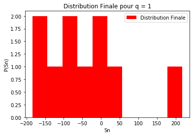

```python
pos_finale1 = []
for i in range(10):
    pos_finale1.append(q1[i][10000])
plt.hist(pos_finale1,color="red",label = "Distribution Finale")
plt.title("Distribution Finale pour q = 1")
plt.xlabel('Sn')
plt.ylabel('P(Sn)')
plt.legend()
plt.show
```

```
<function matplotlib.pyplot.show(*args, **kw)>
```

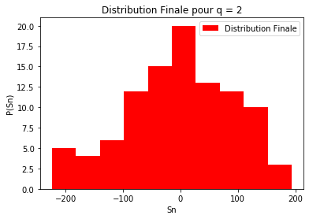

```python
pos_finale2 = []
for i in range(100):
    pos_finale2.append(q2[i][10000])
plt.hist(pos_finale2,color="red",label = "Distribution Finale")
plt.title("Distribution Finale pour q = 2")
plt.xlabel('Sn')
plt.ylabel('P(Sn)')
plt.legend()
plt.show
```

```
<function matplotlib.pyplot.show(*args, **kw)>
```

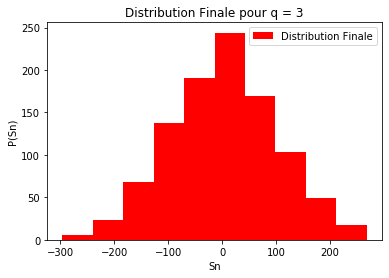

```python
pos_finale3 = []
for i in range(1000):
    pos_finale1.append(q3[i][10000])
plt.hist(pos_finale1,color="red",label = "Distribution Finale")
plt.title("Distribution Finale pour q = 3")
plt.xlabel('Sn')
plt.ylabel('P(Sn)')
plt.legend()
plt.show
```

**Question :** Tracer sur un même graphe $< S_{n} >_{q}$ et $\sqrt{Var(S_{n})_{q}}$ d’une part et $P(S_{N})_{q}$ d’autre part.

**Réponse :**

- $q$ $= 1$

```
<function matplotlib.pyplot.show(*args, **kw)>
```

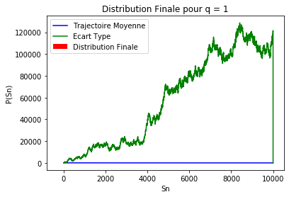

```python
plt.hist(pos_finale1,color="red",label = "Distribution Finale")
plt.plot(moy1,color = "blue",label = "Trajectoire Moyenne")
plt.plot(racine_var1,color = "green",label = "Ecart Type")
plt.title("Distribution Finale pour q = 1")
plt.xlabel('Sn')
plt.ylabel('P(Sn)')
plt.legend()
plt.show
```

- $q$ $= 2$

```
<function matplotlib.pyplot.show(*args, **kw)>
```

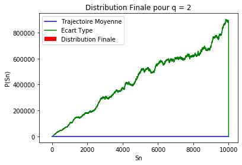

```python
plt.hist(pos_finale2,color="red",label = "Distribution Finale")
plt.plot(moy2,color = "blue",label = "Trajectoire Moyenne")
plt.plot(racine_var2,color = "green",label = "Ecart Type")
plt.title("Distribution Finale pour q = 2")
plt.xlabel('Sn')
plt.ylabel('P(Sn)')
plt.legend()
plt.show
```

- $q$ $= 3$

```
<function matplotlib.pyplot.show(*args, **kw)>
```

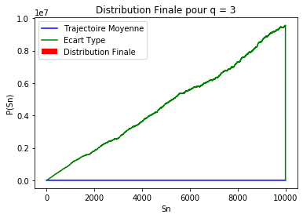

```python
plt.hist(pos_finale3,color="red",label = "Distribution Finale")
plt.plot(moy3,color = "blue",label = "Trajectoire Moyenne")
plt.plot(racine_var3,color = "green",label = "Ecart Type")
plt.title("Distribution Finale pour q = 3")
plt.xlabel('Sn')
plt.ylabel('P(Sn)')
plt.legend()
plt.show
```

### 1.8.1 Question 8 :

Quelle est la fonction qui ajuste cette distribution dans la limite $M ≫ 1$ ? Pourquoi ?

### 1.8.2 Réponse 8 :

la fonction qui ajuste cette distribution dans la limite $M ≫ 1$ est la distribution gaussienne, car on remarque que le nuage des positions finales est en gros centré sur la marche initiale pour $M ≫ 1$

**Justification** : Car sur le régime asymptotique: la loi binomiale se comporte asymptotiquement comme une distribution gaussienne.

## 2. Loi Uniforme :

Les pas de la marche aléatoire sont distribués sur une loi uniforme centréeentre $−0.5$ et $0.5$.

### 2.1.1 Question 1 :

Générer quelques marches aléatoires de $N = 10000$ pas .

### 2.1.2 Réponse 1 :

- On commence par définir une fonction simuler_marche_aléatoire_uniforme qui simule la marche aléatoire.
- Les entrées de la fonction sont : le nombre de pas.
- La fonction retourne un tableau qui représente la marche.

```python
def simuler_marche_aleatoire_uniforme(n):
    s=0
    marche=[s]
    for i in range(n):
        s += np.random.uniform(-0.5,0.5)
        marche.append(s)
    return marche
```

- On génère quelques marches.
- On affiche uniquement les 10 premières position et la position finale des 3 premières simulations.

```python
u1 = [] # tableau qui comporte les marches aléatoires de pas = 10000
for i in range(50):
    m = simuler_marche_aleatoire_uniforme(10000)
    u1.append(m)
for u in u1[:3]:
    print ( 'Les 10 premières position (10 premières valeurs de Sn) de la marche : ',u[:10])
    print ( 'La position finale de la marche : ',u[10000])
    print ('')
```

```
Les 10 premières position (10 premières valeurs de Sn) de la marche :  [0, 0.36309726584936763, -0.027257666296168437, 0.42302039960407467, -0.022176235188417603, 0.23901415071158527, 0.12804250250381732, 0.10989290201628266, 0.154243870825145, 0.30565186150793655]
La position finale de la marche :  41.95282895996684

Les 10 premières position (10 premières valeurs de Sn) de la marche :  [0, -0.30214640904627266, -0.4402670312231941, 0.05920961171552941, 0.0903967345493577, -0.3720641598645734, -0.7906279629513946, -0.8271086606094935, -0.9430839214575609, -1.0303407189453817]
La position finale de la marche :  44.63524751844301

Les 10 premières position (10 premières valeurs de Sn) de la marche :  [0, 0.12213117791810246, 0.5539465674742745, 0.3985534872363633, -0.06599339735588505, 0.20422527996728257, 0.47922865095593314, 0.45758385157161074, 0.1025465240502027, -0.3902181969250993]
La position finale de la marche :  17.967695463050998
```

### 2.2.1 Question 2 :

Tracer une marche aléatoire ($S_{n}$ en fonction de $n$). et la comparer à une marche aléatoire binomiale symétrique.

### 2.2.2 Réponse 2 :

- On trace 3 simulations de marche aléatoire uniforme
- On trace 3 simulations de marche aléatoire binomiale symétrique ( $p=0.5$ )
- On trace toutes les marches sur le meme graphe pour pouvoir comparer.
- Les couleurs sont comme suit :
  - Uniforme ---> couleur Bleue
  - binomiale avec $p=0.5$ ---> couleur Verte

```
<function matplotlib.pyplot.show(*args, **kw)>
```

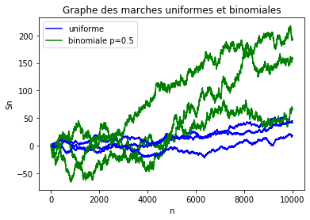

```python
X = np.linspace(0, 10000, 10001)
for i in range(3):
    if (i==0):
        plt.plot(X,u1[i],color = "blue",label="uniforme")
        plt.plot(X,s3[i],color = "green",label="binomiale p=0.5")
    else:
        plt.plot(X,u1[i],color = "blue")
        plt.plot(X,s3[i],color = "green")
plt.title("Graphe des marches uniformes et binomiales")
plt.xlabel('n')
plt.ylabel('Sn')
plt.legend()
plt.show
```

**Comparaison :**

- On remarque que les deux marches se comportent presque de la meme manière .

**Différence :**

- La différence est que la marche aléatoire avec loi uniforme reste plus proche du point du départ que la loi binomiale, ceci revient à la taille du pas ( entre -0.5 et 0.5 ) contrairement a la loi binomiale qui à un pas de soit 1 soit -1.

### 2.6.1 Question 6 :

Générer $M$ $= 10^q$ (d’abord pour $q$ $= 1$, puis $q$ $= 2$, $3$et$4$) marches aléatoires de $N$ $= 10000$ pas et calculer $< S_{n} >_{q}$ et $\sqrt{Var(S_{n})_{q}}$ pour $n$ $≤$ $N$.

### 2.6.2 Réponse 6 :

- $q$ $= 1$

```python
r1 = [] # tableau qui comporte les marches aléatoires uniformes de pas = 10000
for i in range(10):
    m = simuler_marche_aleatoire_uniforme(10000)
    r1.append(m)
moy_u1 = calculer_trajectoire_moyenne(r1)
racine_var_u1 = calculer_racine_variance(r1)
print('Les 10 premières composantes de < Sn > sont : ',moy_u1[:10])
print('Les 10 dernières composantes de < Sn > sont : ',moy_u1[-10:])
print("Les 10 premières composantes de l'ecart type sont : ",racine_var_u1[:10])
print("Les 10 dernières composantes de l'ecart type sont : ",racine_var_u1[-10:])
```

```
Les 10 premières composantes de < Sn > sont :  [0.0, 0.13069180485976975, 0.24587634047933543, 0.2374725300670058, 0.26288724082173004, 0.3584289323459688, 0.4557951929847535, 0.5234398075319142, 0.6110526001576947, 0.6893300123387123]
Les 10 dernières composantes de < Sn > sont :  [-6.907662510275252, -7.048532343216797, -6.962182971555495, -7.016674038264472, -6.953252360471066, -6.892912320032769, -6.84146279493321, -6.843426968637274, -6.773152445258058, -6.657309994777153]
Les 10 premières composantes de l'ecart type sont :  [0.0, 0.9774120383151591, 1.8017147259226007, 3.3463355258604612, 4.097697089791171, 4.714946659909737, 7.231953104556977, 7.160349145118493, 8.93667997138931, 10.928873092181863]
Les 10 dernières composantes de l'ecart type sont :  [7260.817874435632, 7301.660428914886, 7366.312624932745, 7250.557804951619, 7273.7749086096155, 7236.300216758261, 7162.302462754434, 7152.133438385083, 7191.395564637435, 26.751463775627894]
```

- $q$ $= 2$

```python
r2 = [] # tableau qui comporte les marches aléatoires uniformes de pas = 10000
for i in range(100):
    m = simuler_marche_aleatoire_uniforme(10000)
    r2.append(m)
moy_u2 = calculer_trajectoire_moyenne(r2)
racine_var_u2 = calculer_racine_variance(r2)
print('Les 10 premières composantes de < Sn > sont : ',moy_u2[:10])
print('Les 10 dernières composantes de < Sn > sont : ',moy_u2[-10:])
print("Les 10 premières composantes de l'ecart type sont : ",racine_var_u2[:10])
print("Les 10 dernières composantes de l'ecart type sont : ",racine_var_u2[-10:])
```

```
Les 10 premières composantes de < Sn > sont :  [0.0, -0.023709452523538562, 0.04456237750158839, 0.05268286364782632, 0.04238680863148356, 0.000446145156411506, -0.023050883168191785, 0.008814558886247346, 0.0644345056867969, 0.06841408167258742]
Les 10 dernières composantes de < Sn > sont :  [3.9812451287483643, 3.991554937301242, 4.020577171114099, 3.9770745416964086, 4.001095366551181, 4.035346804015172, 4.0433216037879145, 4.014130393891347, 3.985318576659825, 3.972010442374918]
Les 10 premières composantes de l'ecart type sont :  [0.0, 8.667707770561055, 13.660116472282699, 22.963008040197636, 30.33375494110362, 36.777787131721695, 43.317935507867986, 45.47856416185436, 60.69593187103742, 62.487445814189826]
Les 10 dernières composantes de l'ecart type sont :  [83585.38936639654, 83663.2169210006, 83418.52244782526, 83517.90055030062, 83630.94653476893, 83682.63875607669, 83583.37442727496, 83289.69978583122, 83346.64951008237, 28.884369297214565]
```

- $q$ $= 3$

```python
r3 = [] # tableau qui comporte les marches aléatoires uniformes de pas = 10000
for i in range(1000):
    m = simuler_marche_aleatoire_uniforme(10000)
    r3.append(m)
moy_u3 = calculer_trajectoire_moyenne(r3)
racine_var_u3 = calculer_racine_variance(r3)
print('Les 10 premières composantes de < Sn > sont : ',moy_u3[:10])
print('Les 10 dernières composantes de < Sn > sont : ',moy_u3[-10:])
print("Les 10 premières composantes de l'ecart type sont : ",racine_var_u3[:10])
print("Les 10 dernières composantes de l'ecart type sont : ",racine_var_u3[-10:])
```

```
Les 10 premières composantes de < Sn > sont :  [0.0, 0.02097327058339439, 0.014939551096001218, 0.023338292876068586, 0.02607069149860499, 0.03503247151503441, 0.025270113501122397, 0.01415362285454095, 0.002842778098164643, 0.0040694879684763175]
Les 10 dernières composantes de < Sn > sont :  [1.0404208376552873, 1.048888945957074, 1.0586067637914314, 1.057605835412779, 1.0490975207079205, 1.0624478540869833, 1.0600858440271548, 1.0577089750147786, 1.0808052263853358, 1.0910509282942054]
Les 10 premières composantes de l'ecart type sont :  [0.0, 84.18390317837746, 180.64389991256996, 260.84823826689194, 347.63014320995035, 423.71793541713345, 534.0089358944465, 600.9075249673806, 682.9383343278505, 768.0385605195495]
Les 10 dernières composantes de l'ecart type sont :  [801789.8653103997, 801598.4793871788, 802411.4336618199, 802402.4509127877, 802770.7634371837, 802971.1778705149, 802127.3135725498, 802106.0728699418, 802715.4751543598, 28.339090947373975]
```

- $q$ $= 4$

```python
r4 = [] # tableau qui comporte les marches aléatoires uniformes de pas = 10000
for i in range(10000):
    m = simuler_marche_aleatoire_uniforme(10000)
    r4.append(m)
moy_u4 = calculer_trajectoire_moyenne(r4)
racine_var_u4 = calculer_racine_variance(r4)
print('Les 10 premières composantes de < Sn > sont : ',moy_u4[:10])
print('Les 10 dernières composantes de < Sn > sont : ',moy_u4[-10:])
print("Les 10 premières composantes de l'ecart type sont : ",racine_var_u4[:10])
print("Les 10 dernières composantes de l'ecart type sont : ",racine_var_u4[-10:])
```

[output not shown]

### 2.7.1 Question 7 :

Calculer la distribution (ie les histogrammes) $P(S_{N})_{q}$ de la dernière position $S_{N}$ .

### 2.7.2 Réponse 7 :

```
<function matplotlib.pyplot.show(*args, **kw)>
```

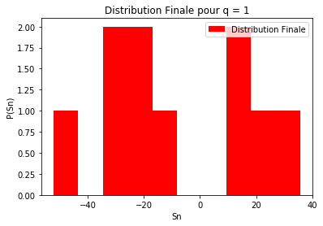

```python
pos_finale_uniforme_1 = []
for i in range(10):
    pos_finale_uniforme_1.append(r1[i][10000])
plt.hist(pos_finale_uniforme_1,color="red",label = "Distribution Finale")
plt.title("Distribution Finale pour q = 1")
plt.xlabel('Sn')
plt.ylabel('P(Sn)')
plt.legend()
plt.show
```

```
<function matplotlib.pyplot.show(*args, **kw)>
```

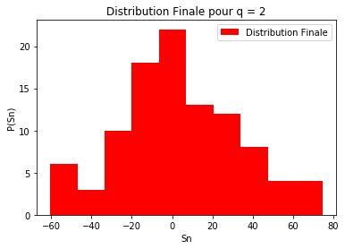

```python
pos_finale_uniforme_2 = []
for i in range(100):
    pos_finale_uniforme_2.append(r2[i][10000])
plt.hist(pos_finale_uniforme_2,color="red",label = "Distribution Finale")
plt.title("Distribution Finale pour q = 2")
plt.xlabel('Sn')
plt.ylabel('P(Sn)')
plt.legend()
plt.show
```

```
<function matplotlib.pyplot.show(*args, **kw)>
```

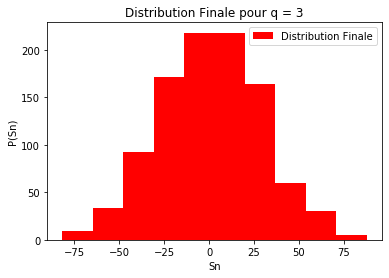

```python
pos_finale_uniforme_3 = []
for i in range(1000):
    pos_finale_uniforme_3.append(r3[i][10000])
plt.hist(pos_finale_uniforme_3,color="red",label = "Distribution Finale")
plt.title("Distribution Finale pour q = 3")
plt.xlabel('Sn')
plt.ylabel('P(Sn)')
plt.legend()
plt.show
```

**Question :** Tracer sur un même graphe $< S_{n} >_{q}$ et $\sqrt{Var(S_{n})_{q}}$ d’une part et $P(S_{N})_{q}$ d’autre part.

**Réponse :**

- $q$ $= 1$

```
<function matplotlib.pyplot.show(*args, **kw)>
```

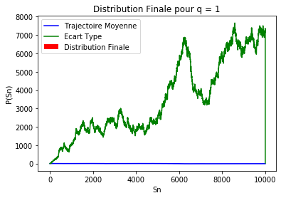

```python
plt.hist(pos_finale_uniforme_1,color="red",label = "Distribution Finale")
plt.plot(moy_u1,color = "blue",label = "Trajectoire Moyenne")
plt.plot(racine_var_u1,color = "green",label = "Ecart Type")
plt.title("Distribution Finale pour q = 1")
plt.xlabel('Sn')
plt.ylabel('P(Sn)')
plt.legend()
plt.show
```

- $q$ $= 2$

```
<function matplotlib.pyplot.show(*args, **kw)>
```

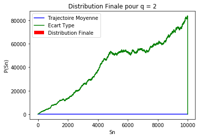

```python
plt.hist(pos_finale_uniforme_2,color="red",label = "Distribution Finale")
plt.plot(moy_u2,color = "blue",label = "Trajectoire Moyenne")
plt.plot(racine_var_u2,color = "green",label = "Ecart Type")
plt.title("Distribution Finale pour q = 2")
plt.xlabel('Sn')
plt.ylabel('P(Sn)')
plt.legend()
plt.show
```

- $q$ $= 3$

```
<function matplotlib.pyplot.show(*args, **kw)>
```

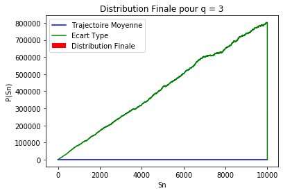

```python
plt.hist(pos_finale_uniforme_3,color="red",label = "Distribution Finale")
plt.plot(moy_u3,color = "blue",label = "Trajectoire Moyenne")
plt.plot(racine_var_u3,color = "green",label = "Ecart Type")
plt.title("Distribution Finale pour q = 3")
plt.xlabel('Sn')
plt.ylabel('P(Sn)')
plt.legend()
plt.show
```

### 2.8.1 Question 8 :

Quelle est la fonction qui ajuste cette distribution dans la limite $M ≫ 1$ ? Pourquoi ?

### 1.8.2 Réponse 8 :

la fonction qui ajuste cette distribution dans la limite $M ≫ 1$ est la distribution gaussienne, car on remarque que le nuage des positions finales est en gros centré sur la marche initiale pour $M ≫ 1$

**Justification** : Car sur le régime asymptotique: la loi uniforme se comporte asymptotiquement comme une distribution gaussienne.